# TeachOSM

## Question 4: Lifespan based on join date?

```python
df.head()
```

| user | first_edit | last_edit | lifespan | total_edits | total_changesets | first_day | last_day |
| --- | --- | --- | --- | --- | --- | --- | --- |
| sejohnson | 2015-06-08 15:29:23 | 2019-08-21 19:39:23 | 1535 | 1776 | 71 | 2015-06-08 | 2019-08-21 |
| Amy_85 | 2015-06-29 15:45:18 | 2019-09-07 19:41:05 | 1531 | 649 | 34 | 2015-06-29 | 2019-09-07 |
| MAPconcierge | 2015-06-18 06:43:19 | 2019-07-31 08:32:53 | 1504 | 12879 | 373 | 2015-06-18 | 2019-07-31 |
| MaggieMaps | 2015-06-14 21:16:25 | 2019-04-18 22:13:38 | 1404 | 2326 | 41 | 2015-06-14 | 2019-04-18 |
| RAytoun | 2015-11-15 22:49:17 | 2019-07-16 10:09:40 | 1338 | 5466 | 47 | 2015-11-15 | 2019-07-16 |

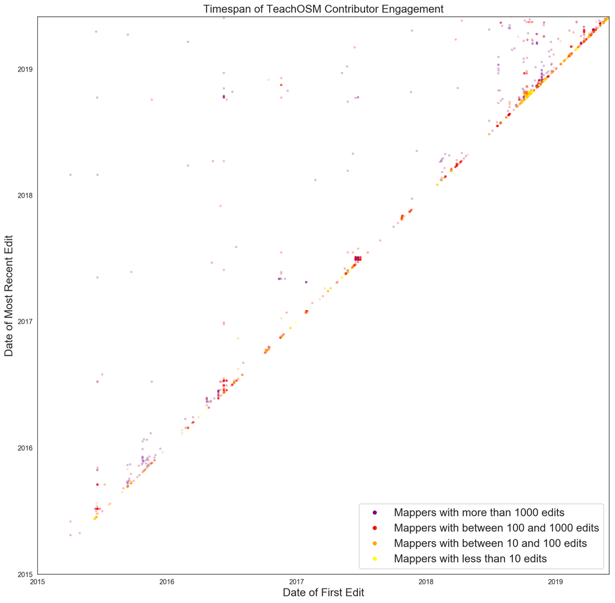

```python
sns.set_style('white')
plt.figure(num=None, figsize=(15, 15), facecolor='w', edgecolor='k')
plt.gca().xaxis.set_major_formatter(mdates.DateFormatter('%Y'))
plt.gca().xaxis.set_major_locator(mdates.YearLocator())
plt.gca().yaxis.set_major_formatter(mdates.DateFormatter('%Y'))
plt.gca().yaxis.set_major_locator(mdates.YearLocator())
plt.xlim([datetime.datetime(2015,1,1),datetime.datetime(2019,6,1)])
plt.ylim([datetime.datetime(2015,1,1),datetime.datetime(2019,6,1)])
plt.xlabel('Date of First Edit', fontsize=16)
plt.ylabel('Date of Most Recent Edit', fontsize=16)
plt.title("Timespan of TeachOSM Contributor Engagement",fontsize=16)

# few_edits  = df[df.sum_edits < 100]
# some_edits = df[((df.sum_edits >= 100) & (df.sum_edits < 1000))]
# most_edits = df[df.sum_edits >= 1000]

few_edits  = df[df.total_edits < 10]
some_edits = df[((df.total_edits >= 10) & (df.total_edits < 100))]
many_edits = df[((df.total_edits >= 100) & (df.total_edits < 1000))]
most_edits = df[df.total_edits >= 1000]

plt.plot(most_edits['first_edit'], most_edits['last_edit'], '.', markersize=5, alpha=0.2,color='purple');
plt.plot(many_edits['first_edit'], many_edits['last_edit'], '.', markersize=5, alpha=0.2,color='red');
plt.plot(some_edits['first_edit'], some_edits['last_edit'], '.', markersize=5, alpha=0.2,color='orange');
plt.plot(few_edits['first_edit'], few_edits['last_edit'], '.', markersize=5, alpha=0.2,color='yellow')

lgnd = plt.legend([
    'Mappers with more than 1000 edits',
    'Mappers with between 100 and 1000 edits',
    'Mappers with between 10 and 100 edits',
    'Mappers with less than 10 edits'
],fontsize=16);

#change the marker size manually for both lines
for lg in lgnd.legendHandles:
    lg._legmarker.set_markersize(10)
    lg._legmarker.set_alpha(1)
```

This particular visualization is a recreation of results from [this paper](https://www.researchgate.net/publication/324557333_The_life_cycle_of_contributors_in_collaborative_online_communities_-the_case_of_OpenStreetMap) by Daniel Bégin et al.

The yellow along the diagonal represent all of the 1-time contributors. However, the faint vertical lines represent mapping events that resulted in mappers sticking around; likewise, horizontal lines represent events where mappers who already had made HOT edits before participated in a single event and then didn't come back again.